# Risk Factor Analysis

## Outcome Variable

**Outcome Variable:** stunted

## Predictor Variables

**Intervention Variable:** perdiar24

**Adjustment Set:**

- arm
- sex
- meducyrs
- hhwealth_quart
- hfoodsec
- hdlvry
- W_birthwt
- W_birthlen
- W_nrooms
- month
- brthmon
- impfloor
- impsan
- safeh20
- delta_meducyrs
- delta_hhwealth_quart
- delta_hfoodsec
- delta_hdlvry
- delta_W_birthwt
- delta_W_birthlen
- delta_W_nrooms
- delta_month
- delta_brthmon
- delta_impfloor
- delta_impsan
- delta_safeh20

## Stratifying Variables

The analysis was stratified on these variable(s):

- agecat
- studyid
- country

## Data Summary

| agecat | studyid | country | perdiar24 | stunted | n_cell | n |
| --- | --- | --- | --- | --- | --- | --- |
| Birth | ki0047075b-MAL-ED | BANGLADESH | 0% | 0 | 16 | 257 |
| Birth | ki0047075b-MAL-ED | BANGLADESH | 0% | 1 | 6 | 257 |
| Birth | ki0047075b-MAL-ED | BANGLADESH | (0%, 5%] | 0 | 126 | 257 |
| Birth | ki0047075b-MAL-ED | BANGLADESH | (0%, 5%] | 1 | 20 | 257 |
| Birth | ki0047075b-MAL-ED | BANGLADESH | >5% | 0 | 68 | 257 |
| Birth | ki0047075b-MAL-ED | BANGLADESH | >5% | 1 | 21 | 257 |
| Birth | ki0047075b-MAL-ED | BRAZIL | 0% | 0 | 97 | 191 |
| Birth | ki0047075b-MAL-ED | BRAZIL | 0% | 1 | 11 | 191 |
| Birth | ki0047075b-MAL-ED | BRAZIL | (0%, 5%] | 0 | 71 | 191 |
| Birth | ki0047075b-MAL-ED | BRAZIL | (0%, 5%] | 1 | 10 | 191 |
| Birth | ki0047075b-MAL-ED | BRAZIL | >5% | 0 | 2 | 191 |
| Birth | ki0047075b-MAL-ED | BRAZIL | >5% | 1 | 0 | 191 |
| Birth | ki0047075b-MAL-ED | INDIA | 0% | 0 | 10 | 206 |
| Birth | ki0047075b-MAL-ED | INDIA | 0% | 1 | 2 | 206 |
| Birth | ki0047075b-MAL-ED | INDIA | (0%, 5%] | 0 | 130 | 206 |
| Birth | ki0047075b-MAL-ED | INDIA | (0%, 5%] | 1 | 26 | 206 |
| Birth | ki0047075b-MAL-ED | INDIA | >5% | 0 | 33 | 206 |
| Birth | ki0047075b-MAL-ED | INDIA | >5% | 1 | 5 | 206 |
| Birth | ki0047075b-MAL-ED | NEPAL | 0% | 0 | 12 | 173 |
| Birth | ki0047075b-MAL-ED | NEPAL | 0% | 1 | 2 | 173 |
| Birth | ki0047075b-MAL-ED | NEPAL | (0%, 5%] | 0 | 96 | 173 |
| Birth | ki0047075b-MAL-ED | NEPAL | (0%, 5%] | 1 | 7 | 173 |
| Birth | ki0047075b-MAL-ED | NEPAL | >5% | 0 | 47 | 173 |
| Birth | ki0047075b-MAL-ED | NEPAL | >5% | 1 | 9 | 173 |
| Birth | ki0047075b-MAL-ED | PERU | 0% | 0 | 25 | 287 |
| Birth | ki0047075b-MAL-ED | PERU | 0% | 1 | 2 | 287 |
| Birth | ki0047075b-MAL-ED | PERU | (0%, 5%] | 0 | 95 | 287 |
| Birth | ki0047075b-MAL-ED | PERU | (0%, 5%] | 1 | 14 | 287 |
| Birth | ki0047075b-MAL-ED | PERU | >5% | 0 | 133 | 287 |
| Birth | ki0047075b-MAL-ED | PERU | >5% | 1 | 18 | 287 |

[output cut: 276 more lines]

The following strata were considered:

- agecat: 24 months, studyid: ki0047075b-MAL-ED, country: BANGLADESH
- agecat: 24 months, studyid: ki0047075b-MAL-ED, country: BRAZIL
- agecat: 24 months, studyid: ki0047075b-MAL-ED, country: INDIA
- agecat: 24 months, studyid: ki0047075b-MAL-ED, country: NEPAL
- agecat: 24 months, studyid: ki0047075b-MAL-ED, country: PERU
- agecat: 24 months, studyid: ki0047075b-MAL-ED, country: SOUTH AFRICA
- agecat: 24 months, studyid: ki0047075b-MAL-ED, country: TANZANIA, UNITED REPUBLIC OF
- agecat: 24 months, studyid: ki1017093-NIH-Birth, country: BANGLADESH
- agecat: 24 months, studyid: ki1017093b-PROVIDE, country: BANGLADESH
- agecat: 24 months, studyid: ki1017093c-NIH-Crypto, country: BANGLADESH
- agecat: 24 months, studyid: ki1114097-CMIN, country: BANGLADESH
- agecat: 24 months, studyid: ki1114097-CMIN, country: GUINEA-BISSAU
- agecat: 24 months, studyid: ki1114097-CMIN, country: PERU
- agecat: 24 months, studyid: ki1114097-CONTENT, country: PERU
- agecat: 24 months, studyid: kiGH5241-JiVitA-4, country: BANGLADESH
- agecat: 6 months, studyid: ki0047075b-MAL-ED, country: BANGLADESH
- agecat: 6 months, studyid: ki0047075b-MAL-ED, country: BRAZIL
- agecat: 6 months, studyid: ki0047075b-MAL-ED, country: INDIA
- agecat: 6 months, studyid: ki0047075b-MAL-ED, country: NEPAL
- agecat: 6 months, studyid: ki0047075b-MAL-ED, country: PERU
- agecat: 6 months, studyid: ki0047075b-MAL-ED, country: SOUTH AFRICA
- agecat: 6 months, studyid: ki0047075b-MAL-ED, country: TANZANIA, UNITED REPUBLIC OF
- agecat: 6 months, studyid: ki1000109-EE, country: PAKISTAN
- agecat: 6 months, studyid: ki1000109-ResPak, country: PAKISTAN
- agecat: 6 months, studyid: ki1000304b-SAS-FoodSuppl, country: INDIA
- agecat: 6 months, studyid: ki1017093-NIH-Birth, country: BANGLADESH
- agecat: 6 months, studyid: ki1017093b-PROVIDE, country: BANGLADESH
- agecat: 6 months, studyid: ki1017093c-NIH-Crypto, country: BANGLADESH
- agecat: 6 months, studyid: ki1112895-Guatemala BSC, country: GUATEMALA
- agecat: 6 months, studyid: ki1114097-CMIN, country: BANGLADESH
- agecat: 6 months, studyid: ki1114097-CMIN, country: BRAZIL
- agecat: 6 months, studyid: ki1114097-CMIN, country: GUINEA-BISSAU
- agecat: 6 months, studyid: ki1114097-CMIN, country: PERU
- agecat: 6 months, studyid: ki1114097-CONTENT, country: PERU
- agecat: 6 months, studyid: kiGH5241-JiVitA-4, country: BANGLADESH
- agecat: Birth, studyid: ki0047075b-MAL-ED, country: BANGLADESH
- agecat: Birth, studyid: ki0047075b-MAL-ED, country: BRAZIL
- agecat: Birth, studyid: ki0047075b-MAL-ED, country: INDIA
- agecat: Birth, studyid: ki0047075b-MAL-ED, country: NEPAL
- agecat: Birth, studyid: ki0047075b-MAL-ED, country: PERU
- agecat: Birth, studyid: ki0047075b-MAL-ED, country: SOUTH AFRICA
- agecat: Birth, studyid: ki0047075b-MAL-ED, country: TANZANIA, UNITED REPUBLIC OF
- agecat: Birth, studyid: ki1000109-EE, country: PAKISTAN
- agecat: Birth, studyid: ki1000109-ResPak, country: PAKISTAN
- agecat: Birth, studyid: ki1017093-NIH-Birth, country: BANGLADESH
- agecat: Birth, studyid: ki1017093c-NIH-Crypto, country: BANGLADESH
- agecat: Birth, studyid: ki1114097-CMIN, country: BANGLADESH
- agecat: Birth, studyid: ki1114097-CMIN, country: BRAZIL
- agecat: Birth, studyid: ki1114097-CMIN, country: PERU
- agecat: Birth, studyid: ki1114097-CONTENT, country: PERU
- agecat: Birth, studyid: kiGH5241-JiVitA-4, country: BANGLADESH

### Dropped Strata

Some strata were dropped due to rare outcomes:

- agecat: Birth, studyid: ki0047075b-MAL-ED, country: BRAZIL
- agecat: Birth, studyid: ki0047075b-MAL-ED, country: INDIA
- agecat: Birth, studyid: ki0047075b-MAL-ED, country: NEPAL
- agecat: Birth, studyid: ki0047075b-MAL-ED, country: PERU
- agecat: Birth, studyid: ki0047075b-MAL-ED, country: SOUTH AFRICA
- agecat: Birth, studyid: ki0047075b-MAL-ED, country: TANZANIA, UNITED REPUBLIC OF
- agecat: Birth, studyid: ki1000109-EE, country: PAKISTAN
- agecat: Birth, studyid: ki1000109-ResPak, country: PAKISTAN
- agecat: Birth, studyid: ki1017093-NIH-Birth, country: BANGLADESH
- agecat: Birth, studyid: ki1017093c-NIH-Crypto, country: BANGLADESH
- agecat: Birth, studyid: ki1114097-CMIN, country: BANGLADESH
- agecat: Birth, studyid: ki1114097-CMIN, country: BRAZIL
- agecat: Birth, studyid: ki1114097-CMIN, country: PERU
- agecat: Birth, studyid: ki1114097-CONTENT, country: PERU
- agecat: 6 months, studyid: ki0047075b-MAL-ED, country: BANGLADESH
- agecat: 6 months, studyid: ki0047075b-MAL-ED, country: BRAZIL
- agecat: 6 months, studyid: ki0047075b-MAL-ED, country: INDIA
- agecat: 6 months, studyid: ki0047075b-MAL-ED, country: NEPAL
- agecat: 6 months, studyid: ki0047075b-MAL-ED, country: PERU
- agecat: 6 months, studyid: ki0047075b-MAL-ED, country: SOUTH AFRICA
- agecat: 6 months, studyid: ki0047075b-MAL-ED, country: TANZANIA, UNITED REPUBLIC OF
- agecat: 6 months, studyid: ki1000109-ResPak, country: PAKISTAN
- agecat: 6 months, studyid: ki1017093b-PROVIDE, country: BANGLADESH
- agecat: 6 months, studyid: ki1114097-CMIN, country: BANGLADESH
- agecat: 6 months, studyid: ki1114097-CMIN, country: BRAZIL
- agecat: 6 months, studyid: ki1114097-CMIN, country: GUINEA-BISSAU
- agecat: 6 months, studyid: ki1114097-CMIN, country: PERU
- agecat: 6 months, studyid: ki1114097-CONTENT, country: PERU
- agecat: 24 months, studyid: ki0047075b-MAL-ED, country: BANGLADESH
- agecat: 24 months, studyid: ki0047075b-MAL-ED, country: BRAZIL
- agecat: 24 months, studyid: ki0047075b-MAL-ED, country: INDIA
- agecat: 24 months, studyid: ki0047075b-MAL-ED, country: NEPAL
- agecat: 24 months, studyid: ki0047075b-MAL-ED, country: PERU
- agecat: 24 months, studyid: ki0047075b-MAL-ED, country: SOUTH AFRICA
- agecat: 24 months, studyid: ki0047075b-MAL-ED, country: TANZANIA, UNITED REPUBLIC OF
- agecat: 24 months, studyid: ki1017093-NIH-Birth, country: BANGLADESH
- agecat: 24 months, studyid: ki1017093b-PROVIDE, country: BANGLADESH
- agecat: 24 months, studyid: ki1114097-CMIN, country: BANGLADESH
- agecat: 24 months, studyid: ki1114097-CONTENT, country: PERU

## Methods Detail

We’re interested in the causal parameters $E[Y_a]$ for all values of $a \in \mathcal{A}$. These parameters represent the mean outcome if, possibly contrary to fact, we intervened to set all units to have $A=a$. Under the randomization and positivity assumptions, these are identified by the statistical parameters $\psi_a=E_W[E_{Y|A,W}(Y|A=a,W)]$. In addition, we’re interested in the mean of $Y$, $E[Y]$ under no intervention (the observed mean). We will estimate these parameters by using SuperLearner to fit the relevant likelihood factors – $E_{Y|A,W}(Y|A=a,W)$ and $p(A=a|W)$, and then updating our likelihood fit using a joint TMLE.

For unadjusted analyses ($W=\{\}$), initial likelihoods were estimated using Lrnr_glm to estimate the simple $E(Y|A)$ and Lrnr_mean to estimate $p(A)$. For adjusted analyses, a small library containing Lrnr_glmnet, Lrnr_xgboost, and Lrnr_mean was used.

Having estimated these parameters, we will then use the delta method to estimate relative risks and attributable risks relative to a prespecified baseline level of $A$.

# Results Detail

## Results Plots

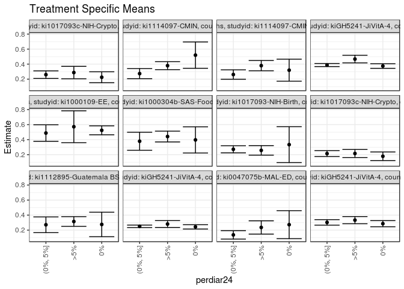

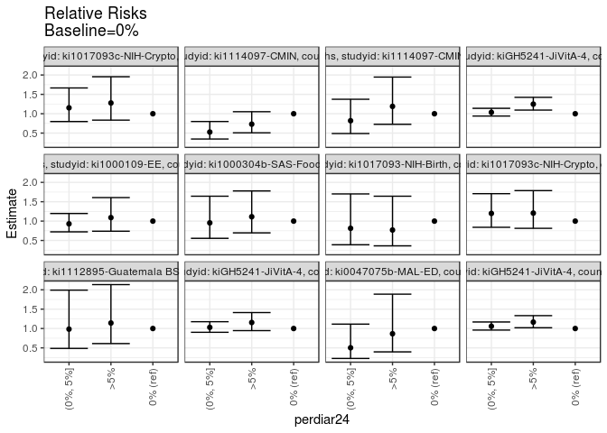

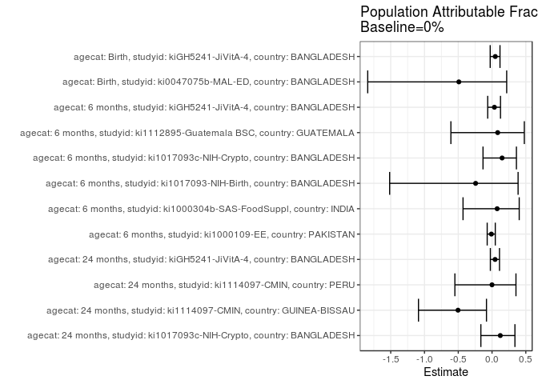

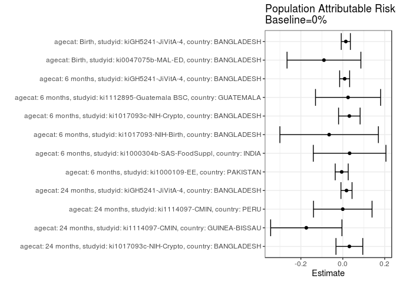

## Results Table

### Parameter: TSM

| agecat | studyid | country | intervention_level | baseline_level | estimate | ci_lower | ci_upper |
| --- | --- | --- | --- | --- | --- | --- | --- |
| Birth | ki0047075b-MAL-ED | BANGLADESH | 0% | NA | 0.2727273 | 0.0862627 | 0.4591918 |
| Birth | ki0047075b-MAL-ED | BANGLADESH | (0%, 5%] | NA | 0.1369863 | 0.0811051 | 0.1928675 |
| Birth | ki0047075b-MAL-ED | BANGLADESH | >5% | NA | 0.2359551 | 0.1475710 | 0.3243391 |
| Birth | kiGH5241-JiVitA-4 | BANGLADESH | 0% | NA | 0.2860340 | 0.2451129 | 0.3269552 |
| Birth | kiGH5241-JiVitA-4 | BANGLADESH | (0%, 5%] | NA | 0.3028773 | 0.2662622 | 0.3394925 |
| Birth | kiGH5241-JiVitA-4 | BANGLADESH | >5% | NA | 0.3333038 | 0.2857758 | 0.3808317 |
| 6 months | ki1000109-EE | PAKISTAN | 0% | NA | 0.5239852 | 0.4644440 | 0.5835265 |
| 6 months | ki1000109-EE | PAKISTAN | (0%, 5%] | NA | 0.4875000 | 0.3778214 | 0.5971786 |
| 6 months | ki1000109-EE | PAKISTAN | >5% | NA | 0.5714286 | 0.3594873 | 0.7833698 |
| 6 months | ki1000304b-SAS-FoodSuppl | INDIA | 0% | NA | 0.3964031 | 0.2221755 | 0.5706307 |
| 6 months | ki1000304b-SAS-FoodSuppl | INDIA | (0%, 5%] | NA | 0.3786388 | 0.2586202 | 0.4986574 |
| 6 months | ki1000304b-SAS-FoodSuppl | INDIA | >5% | NA | 0.4412889 | 0.3692911 | 0.5132866 |
| 6 months | ki1017093-NIH-Birth | BANGLADESH | 0% | NA | 0.3333333 | 0.0945517 | 0.5721150 |
| 6 months | ki1017093-NIH-Birth | BANGLADESH | (0%, 5%] | NA | 0.2713864 | 0.2240064 | 0.3187665 |
| 6 months | ki1017093-NIH-Birth | BANGLADESH | >5% | NA | 0.2568306 | 0.1934736 | 0.3201876 |
| 6 months | ki1017093c-NIH-Crypto | BANGLADESH | 0% | NA | 0.1785340 | 0.1214029 | 0.2356651 |
| 6 months | ki1017093c-NIH-Crypto | BANGLADESH | (0%, 5%] | NA | 0.2139935 | 0.1750258 | 0.2529612 |
| 6 months | ki1017093c-NIH-Crypto | BANGLADESH | >5% | NA | 0.2154324 | 0.1616530 | 0.2692118 |
| 6 months | ki1112895-Guatemala BSC | GUATEMALA | 0% | NA | 0.2758621 | 0.1129200 | 0.4388041 |
| 6 months | ki1112895-Guatemala BSC | GUATEMALA | (0%, 5%] | NA | 0.2714286 | 0.1670791 | 0.3757781 |
| 6 months | ki1112895-Guatemala BSC | GUATEMALA | >5% | NA | 0.3150000 | 0.2505146 | 0.3794854 |
| 6 months | kiGH5241-JiVitA-4 | BANGLADESH | 0% | NA | 0.2436454 | 0.2148595 | 0.2724312 |
| 6 months | kiGH5241-JiVitA-4 | BANGLADESH | (0%, 5%] | NA | 0.2509737 | 0.2344716 | 0.2674759 |
| 6 months | kiGH5241-JiVitA-4 | BANGLADESH | >5% | NA | 0.2814382 | 0.2357254 | 0.3271509 |
| 24 months | ki1017093c-NIH-Crypto | BANGLADESH | 0% | NA | 0.2253853 | 0.1525877 | 0.2981830 |
| 24 months | ki1017093c-NIH-Crypto | BANGLADESH | (0%, 5%] | NA | 0.2598271 | 0.2092462 | 0.3104080 |
| 24 months | ki1017093c-NIH-Crypto | BANGLADESH | >5% | NA | 0.2878772 | 0.2052234 | 0.3705311 |
| 24 months | ki1114097-CMIN | GUINEA-BISSAU | 0% | NA | 0.5198281 | 0.3443557 | 0.6953005 |
| 24 months | ki1114097-CMIN | GUINEA-BISSAU | (0%, 5%] | NA | 0.2739298 | 0.2064183 | 0.3414413 |
| 24 months | ki1114097-CMIN | GUINEA-BISSAU | >5% | NA | 0.3796431 | 0.3263957 | 0.4328906 |
| 24 months | ki1114097-CMIN | PERU | 0% | NA | 0.3193924 | 0.1729076 | 0.4658773 |
| 24 months | ki1114097-CMIN | PERU | (0%, 5%] | NA | 0.2616240 | 0.1990568 | 0.3241912 |
| 24 months | ki1114097-CMIN | PERU | >5% | NA | 0.3799353 | 0.3113104 | 0.4485601 |
| 24 months | kiGH5241-JiVitA-4 | BANGLADESH | 0% | NA | 0.3745215 | 0.3437124 | 0.4053307 |
| 24 months | kiGH5241-JiVitA-4 | BANGLADESH | (0%, 5%] | NA | 0.3877185 | 0.3672687 | 0.4081683 |
| 24 months | kiGH5241-JiVitA-4 | BANGLADESH | >5% | NA | 0.4672886 | 0.4163590 | 0.5182182 |

### Parameter: E(Y)

| agecat | studyid | country | intervention_level | baseline_level | estimate | ci_lower | ci_upper |
| --- | --- | --- | --- | --- | --- | --- | --- |
| Birth | ki0047075b-MAL-ED | BANGLADESH | NA | NA | 0.1828794 | 0.1355257 | 0.2302330 |
| Birth | kiGH5241-JiVitA-4 | BANGLADESH | NA | NA | 0.3004866 | 0.2649179 | 0.3360553 |
| 6 months | ki1000109-EE | PAKISTAN | NA | NA | 0.5188172 | 0.4679751 | 0.5696593 |
| 6 months | ki1000304b-SAS-FoodSuppl | INDIA | NA | NA | 0.4289474 | 0.3791199 | 0.4787748 |
| 6 months | ki1017093-NIH-Birth | BANGLADESH | NA | NA | 0.2681564 | 0.2306532 | 0.3056597 |
| 6 months | ki1017093c-NIH-Crypto | BANGLADESH | NA | NA | 0.2097902 | 0.1799252 | 0.2396552 |
| 6 months | ki1112895-Guatemala BSC | GUATEMALA | NA | NA | 0.3010033 | 0.2489243 | 0.3530824 |
| 6 months | kiGH5241-JiVitA-4 | BANGLADESH | NA | NA | 0.2525357 | 0.2384780 | 0.2665934 |
| 24 months | ki1017093c-NIH-Crypto | BANGLADESH | NA | NA | 0.2568093 | 0.2190047 | 0.2946140 |
| 24 months | ki1114097-CMIN | GUINEA-BISSAU | NA | NA | 0.3457249 | 0.3054989 | 0.3859509 |
| 24 months | ki1114097-CMIN | PERU | NA | NA | 0.3192488 | 0.2749275 | 0.3635701 |
| 24 months | kiGH5241-JiVitA-4 | BANGLADESH | NA | NA | 0.3922559 | 0.3752678 | 0.4092440 |

### Parameter: RR

| agecat | studyid | country | intervention_level | baseline_level | estimate | ci_lower | ci_upper |
| --- | --- | --- | --- | --- | --- | --- | --- |
| Birth | ki0047075b-MAL-ED | BANGLADESH | 0% | 0% | 1.0000000 | 1.0000000 | 1.0000000 |
| Birth | ki0047075b-MAL-ED | BANGLADESH | (0%, 5%] | 0% | 0.5022831 | 0.2265603 | 1.1135593 |
| Birth | ki0047075b-MAL-ED | BANGLADESH | >5% | 0% | 0.8651685 | 0.3967612 | 1.8865673 |
| Birth | kiGH5241-JiVitA-4 | BANGLADESH | 0% | 0% | 1.0000000 | 1.0000000 | 1.0000000 |
| Birth | kiGH5241-JiVitA-4 | BANGLADESH | (0%, 5%] | 0% | 1.0588855 | 0.9593798 | 1.1687119 |
| Birth | kiGH5241-JiVitA-4 | BANGLADESH | >5% | 0% | 1.1652591 | 1.0193668 | 1.3320316 |
| 6 months | ki1000109-EE | PAKISTAN | 0% | 0% | 1.0000000 | 1.0000000 | 1.0000000 |
| 6 months | ki1000109-EE | PAKISTAN | (0%, 5%] | 0% | 0.9303697 | 0.7230893 | 1.1970691 |
| 6 months | ki1000109-EE | PAKISTAN | >5% | 0% | 1.0905433 | 0.7399020 | 1.6073542 |
| 6 months | ki1000304b-SAS-FoodSuppl | INDIA | 0% | 0% | 1.0000000 | 1.0000000 | 1.0000000 |
| 6 months | ki1000304b-SAS-FoodSuppl | INDIA | (0%, 5%] | 0% | 0.9551864 | 0.5553340 | 1.6429409 |
| 6 months | ki1000304b-SAS-FoodSuppl | INDIA | >5% | 0% | 1.1132327 | 0.6966182 | 1.7790045 |
| 6 months | ki1017093-NIH-Birth | BANGLADESH | 0% | 0% | 1.0000000 | 1.0000000 | 1.0000000 |
| 6 months | ki1017093-NIH-Birth | BANGLADESH | (0%, 5%] | 0% | 0.8141593 | 0.3894920 | 1.7018460 |
| 6 months | ki1017093-NIH-Birth | BANGLADESH | >5% | 0% | 0.7704918 | 0.3611877 | 1.6436262 |
| 6 months | ki1017093c-NIH-Crypto | BANGLADESH | 0% | 0% | 1.0000000 | 1.0000000 | 1.0000000 |
| 6 months | ki1017093c-NIH-Crypto | BANGLADESH | (0%, 5%] | 0% | 1.1986149 | 0.8407272 | 1.7088513 |
| 6 months | ki1017093c-NIH-Crypto | BANGLADESH | >5% | 0% | 1.2066745 | 0.8145056 | 1.7876652 |
| 6 months | ki1112895-Guatemala BSC | GUATEMALA | 0% | 0% | 1.0000000 | 1.0000000 | 1.0000000 |
| 6 months | ki1112895-Guatemala BSC | GUATEMALA | (0%, 5%] | 0% | 0.9839286 | 0.4862853 | 1.9908382 |
| 6 months | ki1112895-Guatemala BSC | GUATEMALA | >5% | 0% | 1.1418750 | 0.6111193 | 2.1335909 |
| 6 months | kiGH5241-JiVitA-4 | BANGLADESH | 0% | 0% | 1.0000000 | 1.0000000 | 1.0000000 |
| 6 months | kiGH5241-JiVitA-4 | BANGLADESH | (0%, 5%] | 0% | 1.0300781 | 0.9022415 | 1.1760276 |
| 6 months | kiGH5241-JiVitA-4 | BANGLADESH | >5% | 0% | 1.1551141 | 0.9454179 | 1.4113214 |
| 24 months | ki1017093c-NIH-Crypto | BANGLADESH | 0% | 0% | 1.0000000 | 1.0000000 | 1.0000000 |
| 24 months | ki1017093c-NIH-Crypto | BANGLADESH | (0%, 5%] | 0% | 1.1528128 | 0.7981125 | 1.6651505 |
| 24 months | ki1017093c-NIH-Crypto | BANGLADESH | >5% | 0% | 1.2772669 | 0.8344234 | 1.9551355 |
| 24 months | ki1114097-CMIN | GUINEA-BISSAU | 0% | 0% | 1.0000000 | 1.0000000 | 1.0000000 |
| 24 months | ki1114097-CMIN | GUINEA-BISSAU | (0%, 5%] | 0% | 0.5269623 | 0.3475527 | 0.7989846 |
| 24 months | ki1114097-CMIN | GUINEA-BISSAU | >5% | 0% | 0.7303243 | 0.5067841 | 1.0524672 |
| 24 months | ki1114097-CMIN | PERU | 0% | 0% | 1.0000000 | 1.0000000 | 1.0000000 |
| 24 months | ki1114097-CMIN | PERU | (0%, 5%] | 0% | 0.8191303 | 0.4883224 | 1.3740399 |
| 24 months | ki1114097-CMIN | PERU | >5% | 0% | 1.1895562 | 0.7269457 | 1.9465607 |
| 24 months | kiGH5241-JiVitA-4 | BANGLADESH | 0% | 0% | 1.0000000 | 1.0000000 | 1.0000000 |
| 24 months | kiGH5241-JiVitA-4 | BANGLADESH | (0%, 5%] | 0% | 1.0352368 | 0.9403375 | 1.1397132 |
| 24 months | kiGH5241-JiVitA-4 | BANGLADESH | >5% | 0% | 1.2476949 | 1.0937341 | 1.4233280 |

### Parameter: PAR

| agecat | studyid | country | intervention_level | baseline_level | estimate | ci_lower | ci_upper |
| --- | --- | --- | --- | --- | --- | --- | --- |
| Birth | ki0047075b-MAL-ED | BANGLADESH | 0% | NA | -0.0898479 | -0.2660827 | 0.0863870 |
| Birth | kiGH5241-JiVitA-4 | BANGLADESH | 0% | NA | 0.0144526 | -0.0073159 | 0.0362211 |
| 6 months | ki1000109-EE | PAKISTAN | 0% | NA | -0.0051680 | -0.0362296 | 0.0258935 |
| 6 months | ki1000304b-SAS-FoodSuppl | INDIA | 0% | NA | 0.0325443 | -0.1407856 | 0.2058742 |
| 6 months | ki1017093-NIH-Birth | BANGLADESH | 0% | NA | -0.0651769 | -0.3002043 | 0.1698505 |
| 6 months | ki1017093c-NIH-Crypto | BANGLADESH | 0% | NA | 0.0312562 | -0.0201101 | 0.0826226 |
| 6 months | ki1112895-Guatemala BSC | GUATEMALA | 0% | NA | 0.0251413 | -0.1301396 | 0.1804222 |
| 6 months | kiGH5241-JiVitA-4 | BANGLADESH | 0% | NA | 0.0088903 | -0.0149503 | 0.0327310 |
| 24 months | ki1017093c-NIH-Crypto | BANGLADESH | 0% | NA | 0.0314240 | -0.0325324 | 0.0953804 |
| 24 months | ki1114097-CMIN | GUINEA-BISSAU | 0% | NA | -0.1741032 | -0.3441805 | -0.0040259 |
| 24 months | ki1114097-CMIN | PERU | 0% | NA | -0.0001436 | -0.1399691 | 0.1396819 |
| 24 months | kiGH5241-JiVitA-4 | BANGLADESH | 0% | NA | 0.0177343 | -0.0087498 | 0.0442185 |

### Parameter: PAF

| agecat | studyid | country | intervention_level | baseline_level | estimate | ci_lower | ci_upper |
| --- | --- | --- | --- | --- | --- | --- | --- |
| Birth | ki0047075b-MAL-ED | BANGLADESH | 0% | NA | -0.4912959 | -1.8404579 | 0.2170405 |
| Birth | kiGH5241-JiVitA-4 | BANGLADESH | 0% | NA | 0.0480972 | -0.0271605 | 0.1178410 |
| 6 months | ki1000109-EE | PAKISTAN | 0% | NA | -0.0099612 | -0.0716512 | 0.0481776 |
| 6 months | ki1000304b-SAS-FoodSuppl | INDIA | 0% | NA | 0.0758701 | -0.4294047 | 0.4025373 |
| 6 months | ki1017093-NIH-Birth | BANGLADESH | 0% | NA | -0.2430556 | -1.5158419 | 0.3858171 |
| 6 months | ki1017093c-NIH-Crypto | BANGLADESH | 0% | NA | 0.1489881 | -0.1334835 | 0.3610659 |
| 6 months | ki1112895-Guatemala BSC | GUATEMALA | 0% | NA | 0.0835249 | -0.6090216 | 0.4779892 |
| 6 months | kiGH5241-JiVitA-4 | BANGLADESH | 0% | NA | 0.0352043 | -0.0641979 | 0.1253218 |
| 24 months | ki1017093c-NIH-Crypto | BANGLADESH | 0% | NA | 0.1223632 | -0.1653835 | 0.3390619 |
| 24 months | ki1114097-CMIN | GUINEA-BISSAU | 0% | NA | -0.5035888 | -1.0889265 | -0.0822685 |
| 24 months | ki1114097-CMIN | PERU | 0% | NA | -0.0004499 | -0.5499705 | 0.3542458 |
| 24 months | kiGH5241-JiVitA-4 | BANGLADESH | 0% | NA | 0.0452112 | -0.0246861 | 0.1103405 |